```python
import numpy as np
import matplotlib.pyplot as plt
import pandas as pd
from pandas.plotting import autocorrelation_plot

data_temperature = pd.read_csv("warsaw_temperature.csv", parse_dates=['Date'])
```

# Day 1: Auto-Correlation – Defining the Problem & Selecting the Signal

## 1. Problem Statement (DD01)

Detect recurring patterns (annual cycles) in **Warsaw’s daily average temperature** to help find out **when** and **for how long** average temperatures falls between 0°C and -10°C.

## 2. Use Case (DD02)

City authorities in Warsaw need to **plan and budget** for winter road salting. By confirming the **seasonality** of temperatures in the 0°C to -10°C range, they can better allocate **salt supplies, equipment, and labor** during the times of year.

## 4. Why is This Relevant? (DD04)

- Knowing the pattern of sub-zero temperatures (0°C to -10°C) is **crucial** for road safety: if roads freeze, salting is necessary.
- Understanding **when** and **how often** these temperatures occur helps plan **logistics** and **budgets**.
- The city of Warsaw can **optimize salt usage** which can lead to savings in the city budget.
- Work schedules for personnel responsible for road salting can be better planned.

## 5. Selecting the Signal (DD05, DD06 and DD08)

The data source I'm using is the average day temperature is warsaw merused fro the same device for 1993-2022

Reference: https://www.kaggle.com/datasets/mateuszk013/warsaw-daily-weather/data

## 7. Additional Background (DD07)

In the past few years, the prices of road salt have been dramatically increasing. A few years ago, one ton of road salt cost 200 PLN (45 CHF), but now the price is around 800 PLN (180 CHF) per ton. Last year, because of embargoes on Belarus and Ukraine, Poland experienced a shortage of around 500 thousand tons of road salt. This finding hopefully helps with proper management of road salt so it will be used more effectively, which will bring economic advantages.

## TC1.1c: Could the repetitive pattern be demonstrated via auto-correlation?

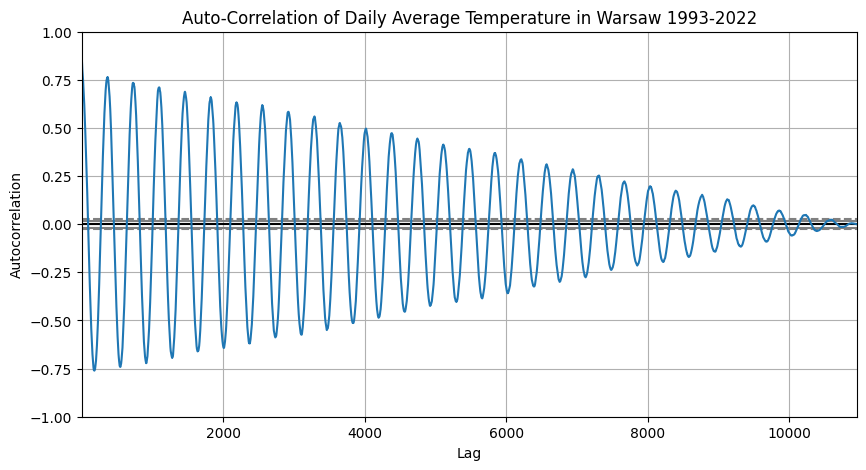

```python
plt.figure(figsize=(10,5))
autocorrelation_plot(data_temperature["Temperature"])
plt.title("Auto-Correlation of Daily Average Temperature in Warsaw 1993-2022")
plt.show()
```

## Auto-Correlation Analysis of Warsaw Temperature Data (1993-2022)

### Key Findings

1. **Strong Seasonal Pattern**
   - Clear yearly cycles (peaks at ~365-day intervals)
   - Strong negative correlation at 180-day intervals
   - Demonstrates reliable temperature seasonality
2. **Correlation Strength**
   - Maximum positive correlation: ~0.75 at yearly intervals
   - Maximum negative correlation: ~-0.75 at half-year intervals
   - Gradual dampening of correlation strength over longer lags

### Conclusion

The auto-correlation analysis reveals robust seasonal patterns in Warsaw's temperature data, indicating that there are cyclic temperature patterns.

## DAY 2: Auto-Correlation – Analyzing Results

## Data Visualization

Let's visualize the data we are working with to visually identify any cyclical patterns.

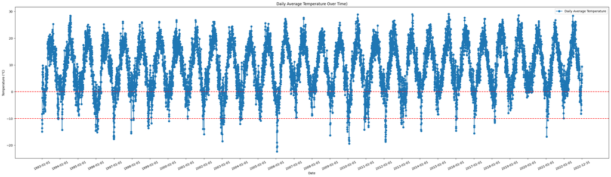

```python
signal = data_temperature['Temperature'].values

plt.figure(figsize=(35, 9))
plt.plot(data_temperature['Date'], signal, marker='o', label='Daily Average Temperature')
plt.title("Daily Average Temperature Over Time)")
plt.xlabel("Date")
plt.ylabel("Temperature (°C)")

years = pd.to_datetime(data_temperature['Date']).dt.year
unique_years = sorted(set(years))

xticks_indices = []
for year in unique_years:
    year_data = data_temperature[pd.to_datetime(data_temperature['Date']).dt.year == year]
    if not year_data.empty:
        xticks_indices.append(year_data.index[0])
xticks_indices.append(data_temperature.index[-1])
xticks = data_temperature['Date'].iloc[xticks_indices].tolist()
plt.xticks(xticks, rotation=25)

plt.axhline(0, color='red', linestyle='--')
plt.axhline(-10, color='red', linestyle='--')

plt.legend()
plt.show()
```

In this chart, we can see that there are temperatures every winter that range between 0 and -10 degrees. There are many days throughout the year when the temperature falls within the desired range.

## Calculate and visualize auto-correlation

```
Peak at lag 362 days with correlation 0.785
Peak at lag 1 years 4 days with correlation 0.789
Peak at lag 1 years 363 days with correlation 0.783
Peak at lag 2 years 3 days with correlation 0.781
Peak at lag 2 years 8 days with correlation 0.775
Peak at lag 2 years 363 days with correlation 0.781
Peak at lag 3 years 4 days with correlation 0.783
```

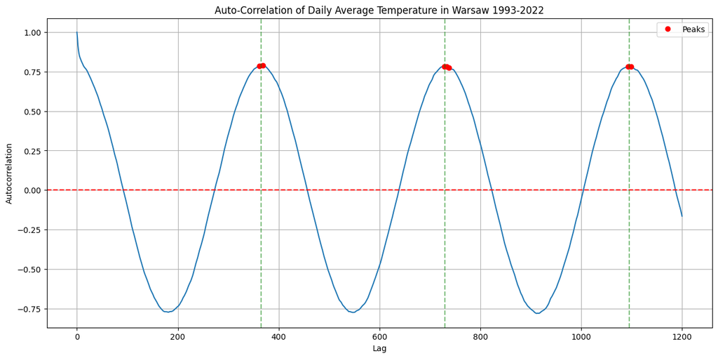

```python
from scipy.signal import find_peaks

lags = 1200
acf = [data_temperature["Temperature"].autocorr(lag=i) for i in range(lags+1)]

peaks, _ = find_peaks(acf, height=0)

plt.figure(figsize=(15,7))
plt.plot(range(len(acf)), acf)
plt.plot(peaks, [acf[i] for i in peaks], "ro", label='Peaks')

plt.title("Auto-Correlation of Daily Average Temperature in Warsaw 1993-2022")
plt.xlabel("Lag")
plt.ylabel("Autocorrelation")
plt.grid(True)
plt.axhline(y=0, color='r', linestyle='--')

for year in range(365, lags, 365):
    plt.axvline(x=year, color='g', linestyle='--', alpha=0.5)

for peak in peaks:
    years = peak // 365
    remaining_days = peak % 365
    if years == 0:
        time_str = f"{remaining_days} days"
    elif remaining_days == 0:
        time_str = f"{years} years"
    else:
        time_str = f"{years} years {remaining_days} days"
    print(f"Peak at lag {time_str} with correlation {acf[peak]:.3f}")

plt.legend()
plt.show()
```

The green vertical lines are represinting passing years (Circulate every 365 days).

On this chart, we can see autocorrelation with 1200 lags (around 3 years, where 1 lag = 1 day in our use case). I calculated the peaks, and it seems they repeat every year.

**Why did I pick 1200 lags?**

- I wanted to calculate the peaks and visualize the data for about 3 years, rather than using the entire dataset, to ensure a clearer visualization.

**Why did I set the height to 0?**

- I set the height to 0 because I didn't want to see negative peaks. In our case, negative peaks would indicate summer time, when the temperature is negatively correlated with winter, which doesn't align with our use case.

## FFT analysis

While autocorrelation can identify periodicities, the FFT provides a direct view of the KPIs, which will help us calculate the period of the changes.

```
FFT-based dominant frequency: 0.0027 (1/days) -> Estimated Period ~ 365.13 days
```

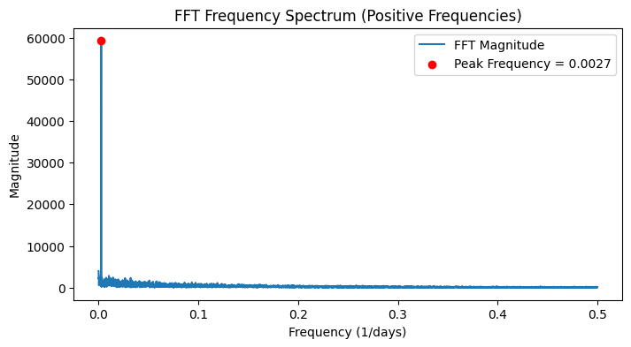

```python
fft_vals = np.fft.fft(signal)
fft_freqs = np.fft.fftfreq(len(signal), d=1)

pos_mask = fft_freqs > 0
fft_vals_pos = fft_vals[pos_mask]
fft_freqs_pos = fft_freqs[pos_mask]

peak_freq_index = np.argmax(np.abs(fft_vals_pos))
peak_freq = fft_freqs_pos[peak_freq_index]
peak_period_fft = 1 / peak_freq

print(f"FFT-based dominant frequency: {peak_freq:.4f} (1/days) -> Estimated Period ~ {peak_period_fft:.2f} days")

plt.figure(figsize=(8, 4))
plt.plot(fft_freqs_pos, np.abs(fft_vals_pos), label='FFT Magnitude')
plt.scatter(peak_freq, np.abs(fft_vals_pos[peak_freq_index]), color='red', zorder=5,
            label=f'Peak Frequency = {peak_freq:.4f}')
plt.title("FFT Frequency Spectrum (Positive Frequencies)")
plt.xlabel("Frequency (1/days)")
plt.ylabel("Magnitude")
plt.legend()
plt.show()
```

These results are aligned with what was expected. The calculated period is 365.13 days, while one year is actually 365.25 days.